# OpenAlex as the Literature Database of Choice of IPBES

White Paper

Author

Affiliation

Rainer M Krug

Swiss Institute of Bioinformatics

Published

April 7, 2026

Doi

10.5281/zenodo.19001084

*For any inquires please contact aidin.niamir@senckenberg.de*

**GitHub Repo: https://github.com/IPBES-Data/IPBES_WP_OpenAlex**

## Glossary

- API: Application Programming Interface. An interface to query the database programmatically.
- data snapshot: A snapshot of the data which can be downloaded for local use.
- linked open data: Representing a document (in IPBES context at the moment the assessments) in a structured format which allows linking of the documents with each other and also other documents available. It provides structure to the text, and includes cross links.

## Introduction

This white paper evaluates [OpenAlex](https://openalex.org) as a recommended data source for IPBES assessments of scholarly literature, compared to [Web of Science](https://www.webofscience.com/wos/) and [Scopus](https://www.scopus.com/). The focus is on its use within IPBES, emphasizing the transparency of academic literature searches.

In IPBES assessments, the main sources for scholarly literature search were [Web of Science](https://www.webofscience.com/wos/) and [Scopus](https://www.scopus.com/). These were mainly used via the web interface due to licensing limitations and complexities in the API. The use of the web interface poses a considerable problem regarding transparency and reproducibility of the search. In addition, neither the data used of these scholarly data sources nor the code which is used to conduct the search or the API implementation is openly available. As literature forms the foundation of most aspects in IPBES assessments, this lack of transparency filters through to the final product.

The Data and Knowledge Management Policy (https://www.ipbes.net/node/38260 and https://doi.org/10.5281/zenodo.3551078) aims to enhance the transparency of IPBES products. An option to the replace the proprietary scholarly data sources is [OpenAlex](https://openalex.org). Unlike the proprietary and restricted scholarly data sources, [OpenAlex](https://openalex.org) is open, free to use, and both the data and code are openly accessible under the [CC0 license](https://creativecommons.org/public-domain/cc0/).

The data and knowledge TF and tsu therefore decided to assess the suitability of OpenAlex as a replacement for the proprietary scholarly data sources in the context of IPBES, with particular focus on the needs of the assessments. Based on this initial assessment and the initial usage in assessments, we recommend the usage of OpenAlex instead of proprietary scholarly data sources.

This document will detail differences between these scholarly data sources and outline the advantages of OpenAlex over WoS and Scopus.

## Advantages OpenAlex in comparison to other databases

The comparison needs to be done in several aspects which are:

- Number of works in the data source and number of OpenAccess works
- Coverage (e.g Global South, academic, grey literature, etc)
- Openness of data and code used
- Web and API Access
- costs for usage

We will go through these points in more detail now.

### Available Works and Number of OpenAccess works

OpenAlex was seeded with data from [Microsoft Academic](https://aka.ms/msracad) when it was retired in 2021. The data was then enriched with data from [Crossref](https://www.crossref.org/) and is continuously updated from several sources (See [here](https://openalex.org/about#Sources)). Recently there was a huge increase in works available in OpenAlex du=t to ingestion of additional data sources.

Most works in OpenAlex are ingested via Crossref, but a large proportion are from other sources.

> […] when restricted to a cleaned dataset of 16,788,282 recent publications shared by all three databases, OpenAlex has average reference numbers comparable to both Web of Science and Scopus.

This is also clearly illustrated clearly by Figure 1 from the article.

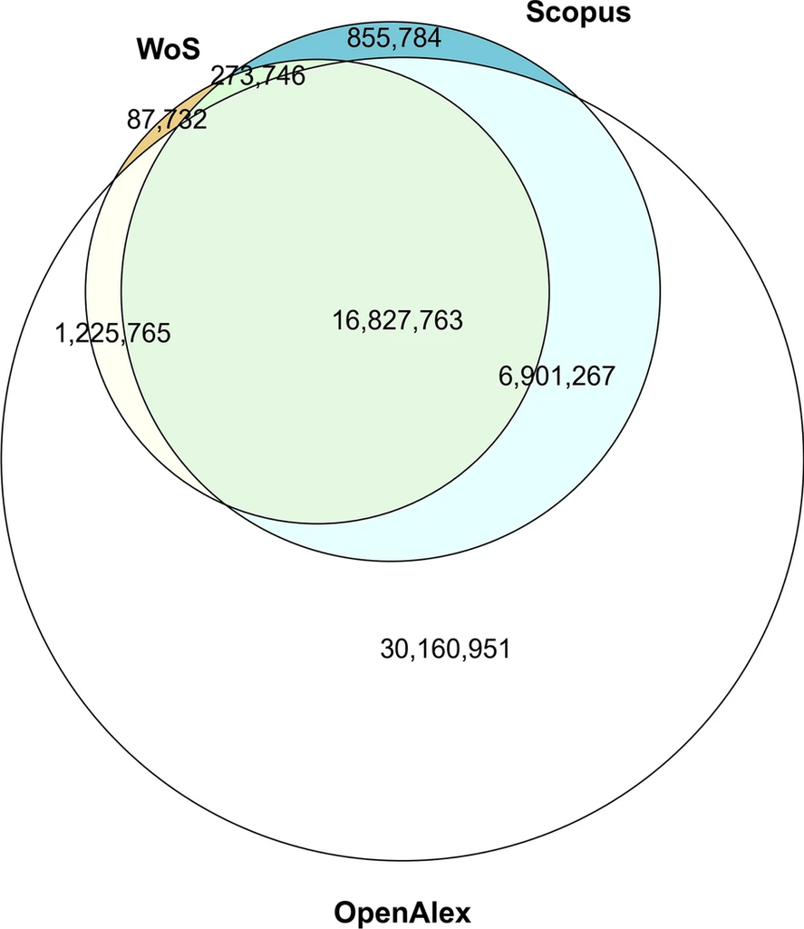

Figure 1: Venn diagram of the intersection sizes of unique DOIs based in each database on exact DOI match (without deduplication, i.e. cases of DOIs that have been assigned to multiple papers are now kept in the sets), for records published between 2015 and 2022 (Source for caption and figure: Culbert et al. (2025), Figure 1).

### Coverage (e.g Global South, academic, grey literature, etc)

OpenAlex has a broad coverage from the Global South. It also has a large proportion of non-academic works as well as works without DOIs, i.e. including reports and data.

[Alonso-Alvarez & van Eck](https://arxiv.org/abs/2409.01120) analysed the coverage and metadata of African publications in particular, and came to the conclusion, that

> Our analysis shows that OpenAlex offers the most extensive publication coverage. In terms of metadata, OpenAlex offers a high coverage of publication and author information. It performs worse regarding affiliations, references, and funder information. Importantly, our results also show that metadata availability in OpenAlex is better for publications that are also indexed in Scopus or WoS.

The always updated numbers of the coverage of OpenAlex can be found at https://openalex.org/stats. Here is a snapshot:

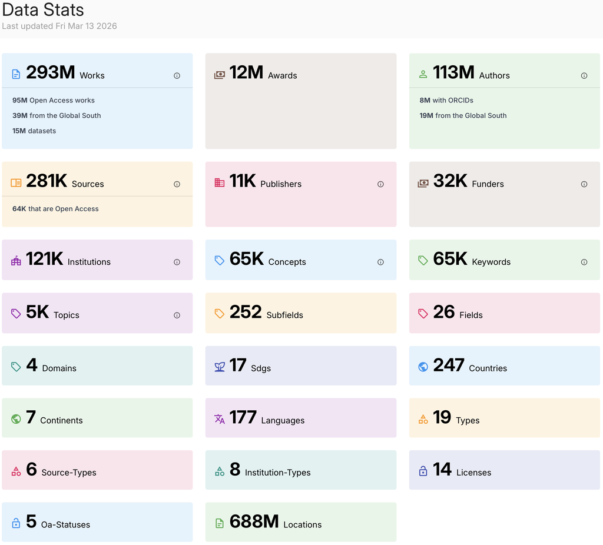

Figure 2: Data Stats from Open alex. Live webpage at https://openalex.org/stats

### Openness of Data and Code used

OpenAlex is free and open, i.e. it is free to use for everybody without any subscription or registration, by design. The data is freely available by downloading a data snapshot by following the [instructions on OpenAlex](https://docs.openalex.org/download-all-data/openalex-snapshot). The datasets can therefore be analysed locally using approaches which are not provisioned for in the API.

### Web and API Access

API access is important for accessing the database programmatically. An example is a search for all articles covering a specific topic. Usually, this is an iterative process which needs refinement of the search terms. The traditional way is to type the search term in the search box and and write down at least the number of hits, change the search term and repeat the process. Especially when other comparisons should also be done (e.g. assessment of certain key-papers are in the search results), this becomes a very tedious and error prone process.

This process can be automated by using the API. In this case, the search is defined e.g. in [R(https://cran.r-project.org)] or any other programming language and the search is done programmatically. The results can then be analysed and the search terms can be refined in a reproducible way with transparent criteria. The results can be shown in a clear, concise and reproducible automatically generated report.

Nevertheless, web access to conduct manual searches is a valuable tool to conduct initial testing of search terms.

In addition to the web interface, most scholarly sources, with the notable exception of google scholar, have an API which can be used to access the data programmatically.

In contrast to the APIs assessed, (WoS, Scopus), the [OpenAlex API](https://docs.openalex.org) is relatively simple but provides all the necessary functionality needed for all IPBES related tasks. For more complex searches or analysis, a data snapshot can be stored and analysed locally.

To simplify the API usage even more, the excellent R package [openalexR](https://docs.ropensci.org/openalexR/articles/A_Brief_Introduction_to_openalexR.html) is available to access the API from [R](https://www.r-project.org/). As this package had limitations, the package openalexPro which overcomes severe limitations of the [openalexR](https://docs.ropensci.org/openalexR/articles/A_Brief_Introduction_to_openalexR.html) package regarding working with large literature corpora. openalexPro has been successfully been used in the Transformative Change Assessment (4.5 million works) as well as is used in the Spatial Planning and Connectivity Assessment.

Some limitations to the use of the API apply:

1. The usage of the GUI (https://openalex.org) is free for everybody
2. To use the API, a free API key is needed which gives enough credits for most research tasks (see [OpenAlex Documentation](https://developers.openalex.org/guides/authentication) for details).

From the free account, you can do the following API calls daily (from [OpenAlex Documentation](https://developers.openalex.org/guides/authentication)):

| Action | Calls | Results | Example |
| --- | --- | --- | --- |
| Get a single entity | Unlimited | Unlimited | Look up a work by DOI |
| List+filter | 10,000 | 1,000,000 | All works from MIT in 2024 |
| Search | 1,000 | 100,000 | Full-text search for “CRISPR” |
| Content download | 100 | 100 PDFs | Download a paper’s full text |

### Costs

OpenAlex is free to use, which is not the case for most other databases. If the limit for free usage limits as outlined above are not enough, a Premium subscription can be obtained (the tsu has obtained a Premium license free of charge due to extensive feed back and extensive discussions with OpenAlex). Please contact the tsu first before enquiring at OpenAlex for higher limits.

For nearly all usage scenarios within IPBES, the free tier is more than enough. As an alternative approach, a data snapshot, which is also simplified by the openalexPro package.

In contrast, the API costs for WoS can easily go into 10s of thousands per dollars per year, and if a data snapshot is required even in the millions. In addition, none of the offered smaller API licenses covers the needs of IPBES, i.e. download of diverse metadata as well as download of a large nuber of works.

## Experience using OpenAlex

OpenAlex was used in the Transformative Change Assessment to fulfil several requests from the experts. The use of OpenAlex was suggested by the data and knowledge tsu to the experts and the experts decided to use OpenAlex. The main reason was that the analysis and search they had planned would have been essentially not possible with scopus or WoS due to limitations of the GUI and non-availability (and limitations) of the APIs.

OpenAlex together with openalexPro enabled us to compile and download the Transformative Change Corpus (TCA Corpus), consisting of 4.5 million works. The works were downloaded, searches in the TCA Corpus were done for several aspects of the TCA and evidence was produced which was considered by the authors as very important to underline their research as well as show venues for additional focal points within the assessment as well as further research based on the assessment.

As a follow up based on the TCA Corpus, a paper was recently published (Reyes-García et al. 2026) which analysed the TCA Corpus further.

OpenAlex also enabled us to do a second kind of search, i.e. a snowball search (following the citation graph from selected key papers one generation back and one generation forward). This very focussed search is easily possible in OpenAlex via the API and the respective R package ([openalexR](https://docs.ropensci.org/openalexR/articles/A_Brief_Introduction_to_openalexR.html) or openalexPro), and has been used in the TCA as well as several times in the Business and Biodiversity Assessment to obtain corpora of focussed literature to, im most cases, find additional evidence for certain points. It is also in usage for the Monitoring Assessment, which is at the moment conducting at least one snowball and one larger keyword search using OpenAlex.

Examples of successful usage of OpenAlex based snowball searches are in IPBES is the Business and Biodiversity Assessment which used these for multiple chapters (either conducted by the tsu or from the fellows).

Another use case within IPBES which allows to discover literature related to identified knowledge gaps in assessments was done as a pilot for the Global Assessment 2. It uses the LOD to identify all references linked to an identified gap (`gap` –> `Sub-chapter` –> `referemnces used in sub-chapter`). OpenAlex was then used, together with a forward Snowball Search to identify articles which cited the articles from the sub-chapter the gap referred to. This provides a corpus of newer articles related to the gap which can be further analysed to assess progress in filling the gap. Further work on this approch will be done to fine tune it and increase it’s usability.

Recent changes in the OpenAlex API include additions of new search types, like similarity search[^1], where the search is done based on similarity between the supplied terms (or text) and the actual work. This opens many possibility to find new literature. It needs to be noted that this is still in beta (development) stage wherefore tha actual implementation can change. Usage for assessments is at the moment not yet recommended, but use cases will be evaluate.

Another addition is pdf[^2] download of the articles from OpenAlex for Open Acces articles. In other words, it is possible to implement the workflow

`define a search term` –> `find articles on OpenAlex` –> `download bibliographic data` –> `download pdf`.

Overall, the experience with using OpenAlex within IPBES has been very positive and, as multiple requests from outside IPBES indicate, on the front of literature search methodologies in general.

## Conclusion

We therefore recommend OpeAlex as the preferred scholarly data sources for IPBES as it is a suitable, and even more powerful replacement for WoS and Scopus.

Furthermore, recent changes and further developments in OpenAlex open the door for new approaches on how to work with literature which were not possible (or exceedingly expensive and complex) with other data sources.

## References

Culbert, Jack H., Anne Hobert, Najko Jahn, et al. 2025. “Reference Coverage Analysis of OpenAlex Compared to Web of Science and Scopus.” *Scientometrics* 130 (4): 2475–92. https://doi.org/10.1007/s11192-025-05293-3.

Reyes-García, Victoria, Rainer M. Krug, Arun Agrawal, et al. 2026. “Actions and Actors Driving Transformative Change for Global Sustainability.” *Nature Sustainability*, ahead of print, February. https://doi.org/10.1038/s41893-026-01783-1.

## Footnotes

[^1]: **Technical note**: Similarity search is effectively a vector search using embeddings and can for example can be easily be used for AI applications like RAG systems.
[^2]: **Technical note**: In addition to pdf, OpenAlex also supplies the articles in `xml` format. It ius generated by sending the pdf article through [GROBID](https://github.com/grobidOrg/grobid) which parses the article into traditional publication metadata to full text structures. Please see [GROBID](https://github.com/grobidOrg/grobid) for further details. This format is also perfectly suited for further processing odf gthe articles.